# Análisis Multivariado - Clase 1

## Motivación

## Experimento

Supongamos que un grupo de investigación tiene como objetivo analizar el impacto de distintos hábitos sobre el rendimiento tanto físico como cognitivo de sus participantes.

Con tal fin, establecen dos exámenes (uno “físico” y otro “cognitivo”) que permiten evaluar mediante un puntaje las condiciones de cada individuo.

Además, se consideran que las siguientes variables pueden influir sobre dichos rendimientos:

- Nivel de hidratación
- Nivel de alimentación
- Tiempo dedicado a las pantallas
- Tiempo dedicado al sueño

## Rendimientos en pruebas físicas y cognitivas

Observamos las primeras filas de la base para inspeccionarla.

```r
head(DatSim)
```

```
##   Hidratación Alimentación Pantallas     Sueño      Test  Puntaje
## 1    94.69166    102.19951  91.10375  98.77666 Cognitivo 214.7968
## 2    97.82053    102.75819 105.44395 117.37921 Cognitivo 224.4305
## 3   101.56877    100.60776 106.35822 106.98909    Físico 203.7226
## 4   101.93731    104.98654  90.82423  93.58370    Físico 191.1300
## 5    95.64230     97.20868  85.99073 104.62088 Cognitivo 236.1101
## 6    97.10112    101.68953 111.76633 116.04422 Cognitivo 208.3873
```

## Descripción

Además, podemos inspeccionar el tipo de cada variable

```r
str(DatSim)
```

```
## 'data.frame':    1000 obs. of  6 variables:
##  $ Hidratación : num  94.7 97.8 101.6 101.9 95.6 ...
##  $ Alimentación: num  102.2 102.8 100.6 105 97.2 ...
##  $ Pantallas   : num  91.1 105.4 106.4 90.8 86 ...
##  $ Sueño       : num  98.8 117.4 107 93.6 104.6 ...
##  $ Test        : Factor w/ 2 levels "Cognitivo","Físico": 1 1 2 2 1 1 1 1 1 2 ...
##  $ Puntaje     : num  215 224 204 191 236 ...
```

## Preguntas

- ¿Cómo evaluamos el impacto de cada variable sobre el puntaje?
- ¿Hay impactos diferentes de alguna variable para los distintos test?
- ¿Hay **combinaciones** de variables que tengan más impacto sobre los puntajes que otras? Dado el caso, ¿Cómo podemos identificarlas?

## Análisis univariado

## Análisis univariado

Antes de hablar de análisis multivariado, deberíamos tener claro qué es un análisis univariado.

Un análisis univariado busca capturar las características de una única variable de una base de datos, sin vincularla con otras.

Cuando se considera una variable **cuantitativa** y **continua**, un análisis univariado que se puede realizar es haciendo un histograma, gráfico que nos permite evaluar qué valores son más frecuentes que otros y además, qué forma tiene dicha distribución de frecuencias.

## Hidratación

Analizamos la distribución de la variable de hidratación. ¿Qué observa?

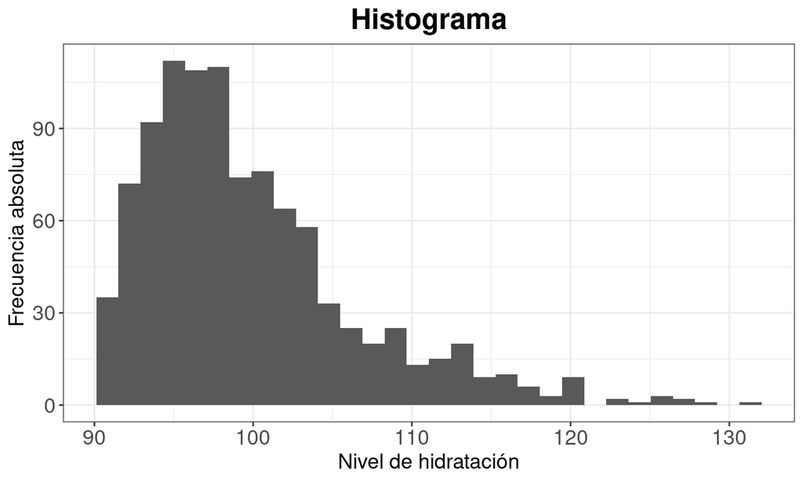

## Alimentación

Analizamos la distribución de la variable de alimentación. ¿Qué observa?

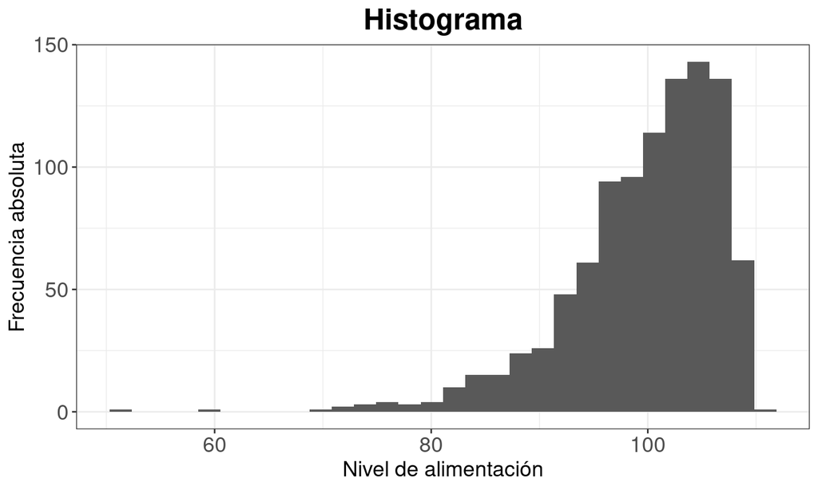

## Pantallas

Analizamos la distribución de la variable nivel de uso de pantallas. ¿Qué observa?

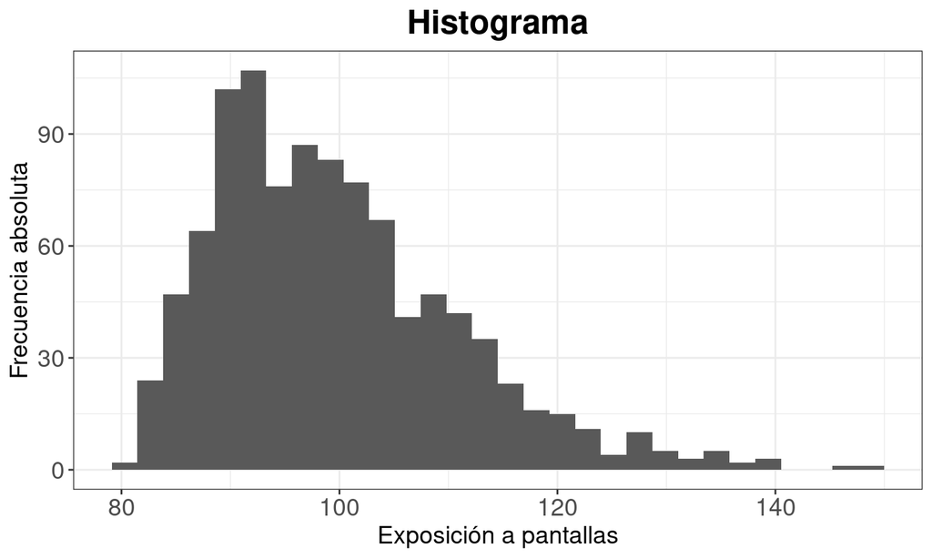

## Sueño

Analizamos la distribución de la variable calidad de sueño. ¿Qué observa?

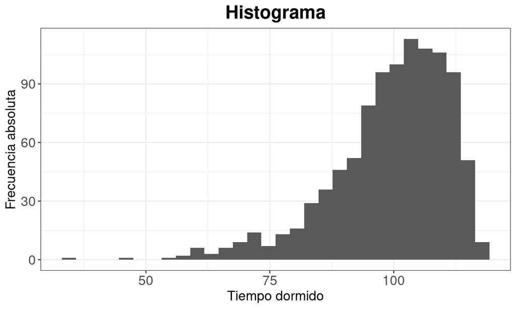

## Puntajes

Analizamos la distribución de la variable de puntajes de los distintos tests. ¿Qué observa?

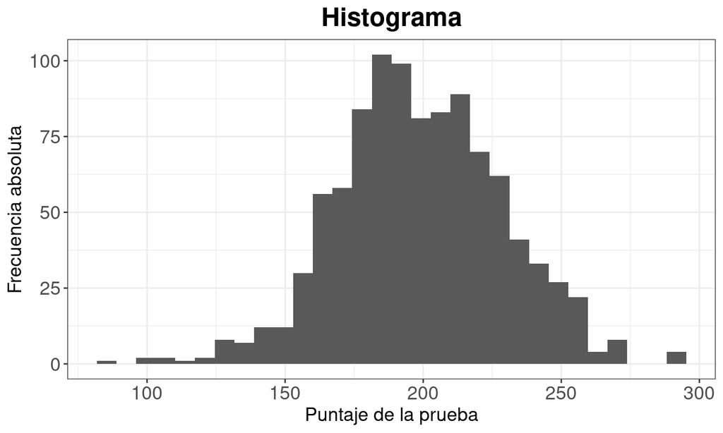

## Conclusiones

- **Hidratación:** Se observa una distribución asimétrica a derecha.
- **Alimentación:** Se observa una distribución asimétrica a izquierda.
- **Pantallas:** Se observa una distribución asimétrica a derecha.
- **Sueño:** Se observa una distribución asimétrica a izquierda.
- **Puntaje:** Se observa una distribución relativamente simétrica (a priori, podríamos considerar que se distribuye como una variable normal).

## Análisis univariado por grupos

## Análisis univariado por grupos

A veces, el análisis de una variable en toda la base de datos no ofrece una perspectiva precisa, ya que esa misma variable se puede comportar de manera distinta en diferentes grupos.

De algún modo, estamos viendo si hay vínculo entre una variable y otra variable **cualitativa**. Para lograrlo, podemos considerar en este caso una comparación de los histogramas correspondientes a cada grupo.

## Hidratación

Analizamos la distribución de la variable de hidratación separado por tipo de test. ¿Se observan diferencias?

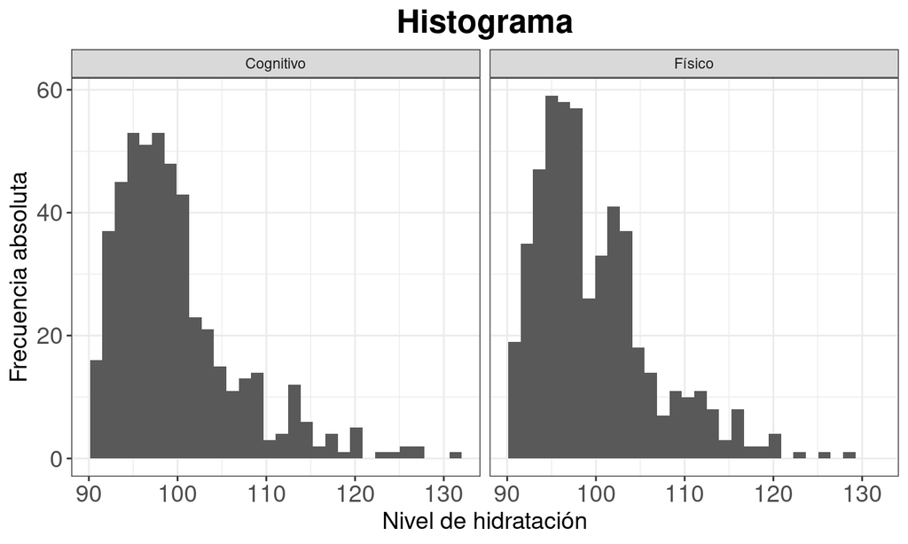

## Alimentación

Analizamos la distribución de la variable de alimentación separado por tipo de test. ¿Se observan diferencias?

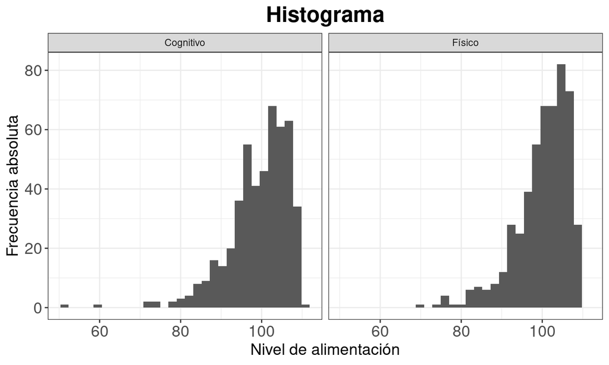

## Pantallas

Analizamos la distribución de la variable de nivel de uso de pantallas separado por tipo de test. ¿Se observan diferencias?

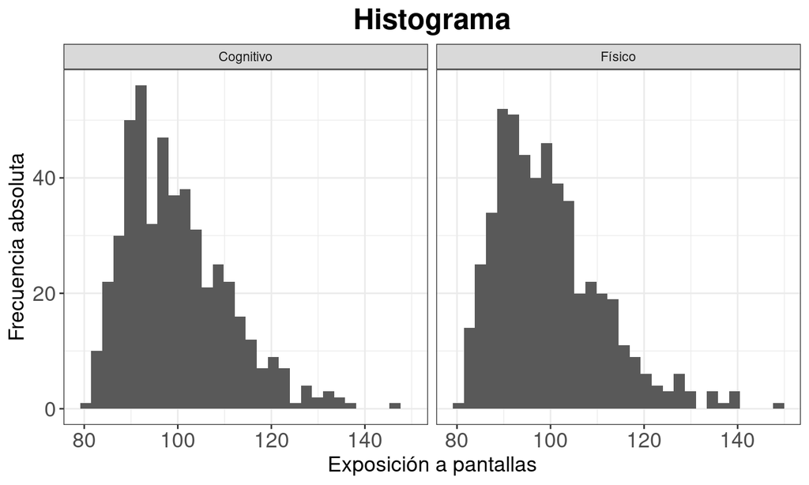

## Sueño

Analizamos la distribución de la variable de calidad de sueño separado por tipo de test. ¿Se observan diferencias?

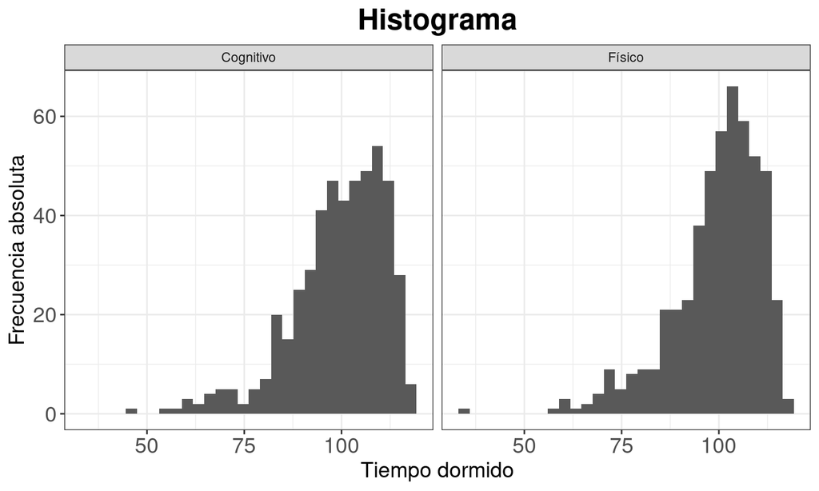

## Puntajes

Analizamos la distribución de la variable de puntaje obtenido separado por tipo de test. ¿Se observan diferencias?

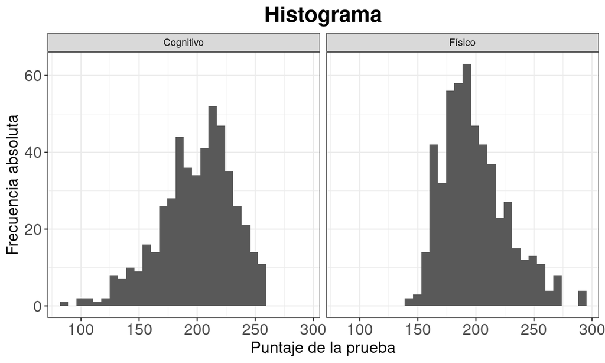

## Conclusiones

- **Hidratación:** No se observan diferencias en las distribuciones de los niveles de hidratación entre los grupos que fueron asignados al test físico y al cognitivo.
- **Alimentación:** No se observan diferencias en las distribuciones de los niveles de alimentación entre los grupos que fueron asignados al test físico y al cognitivo.
- **Pantallas:** No se observan diferencias en las distribuciones de los tiempos dedicados a las pantallas entre los grupos que fueron asignados al test físico y al cognitivo.
- **Sueño:** No se observan diferencias en las distribuciones de los tiempos dedicados al sueño entre los grupos que fueron asignados al test físico y al cognitivo.

## Conclusiones

- **Puntaje:** Se observa una clara diferencia entre ambos grupos, la distribución de los puntajes en el grupo de test cognitivo es asimétrica a izquierda y la del test físico es asimétrica a derecha. Por lo tanto, la primer conclusión de normalidad pierde vigencia ya que se trata de una compensación entre dos variables asimétricas.

Este es un claro ejemplo de cómo nuestra primer impresión puede ser incorrecta, si no somos suficientemente específicos.

## Análisis bivariado

## Análisis bivariado

El análisis bivariado intenta capturar vínculos entre 2 variables.

Nuevamente, en este análisis se descarta la influencia de otras variables.

Para dos variables **cuantitativas** y **continuas** una buena forma de evaluar el vínculo es con un gráfico de dispersión o scatterplot.

## Hidratación vs. Alimentación

Analizamos gráficamente el vínculo entre la variable de hidratación con la variable de alimentación. ¿Observa algún vínculo?

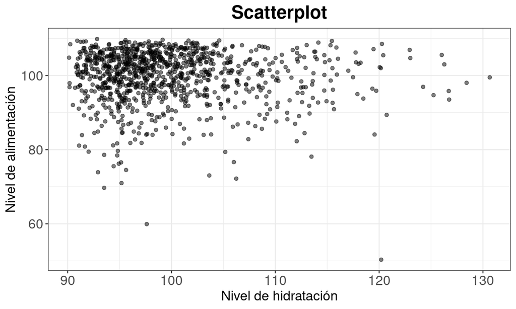

## Hidratación vs. Pantallas

Analizamos gráficamente el vínculo entre la variable de hidratación con la variable de uso de pantallas. ¿Observa algún vínculo?

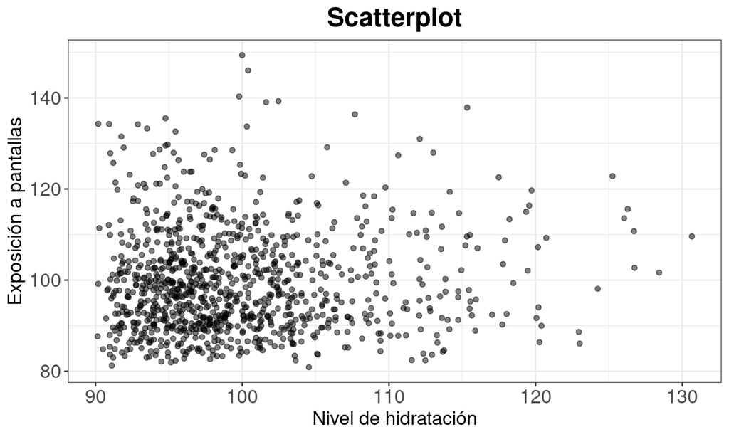

## Hidratación vs. Sueño

Analizamos gráficamente el vínculo entre la variable de hidratación con la variable de calidad de sueño. ¿Observa algún vínculo?

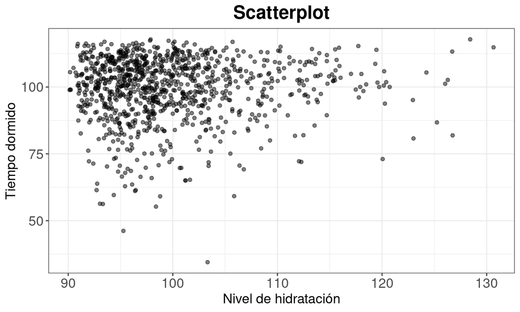

## Hidratación vs. Puntaje

Analizamos gráficamente el vínculo entre la variable de hidratación con la variable de puntaje obtenido. ¿Observa algún vínculo?

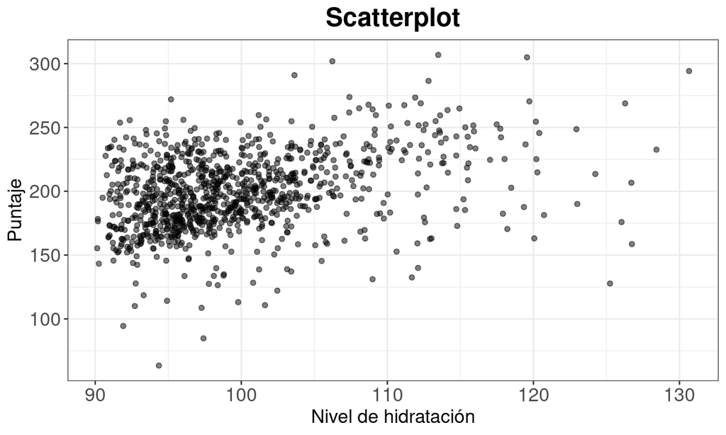

## Alimentación vs. Pantallas

Analizamos gráficamente el vínculo entre la variable de alimentación con la variable de uso de pantallas. ¿Observa algún vínculo?

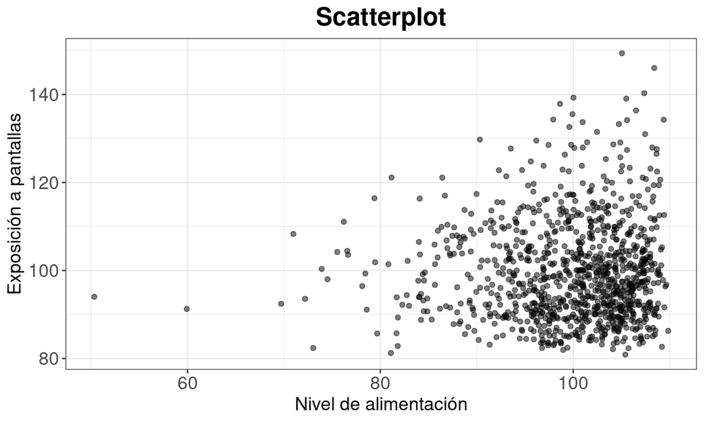

## Alimentación vs. Sueño

Analizamos gráficamente el vínculo entre la variable de alimentación con la variable de calidad de sueño. ¿Observa algún vínculo?

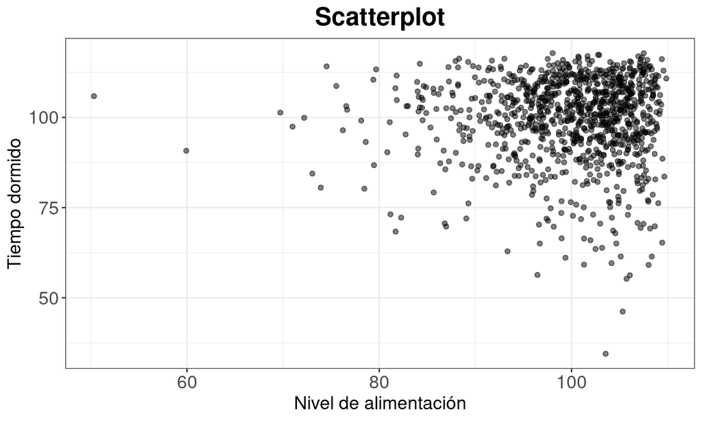

## Alimentación vs. Puntaje

Analizamos gráficamente el vínculo entre la variable de alimentación con la variable de puntaje obtenido. ¿Observa algún vínculo?

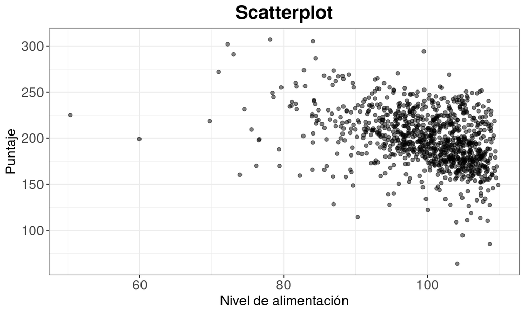

## Pantallas vs. Sueño

Analizamos gráficamente el vínculo entre la variable de uso de pantallas con la variable de calidad de sueño. ¿Observa algún vínculo?

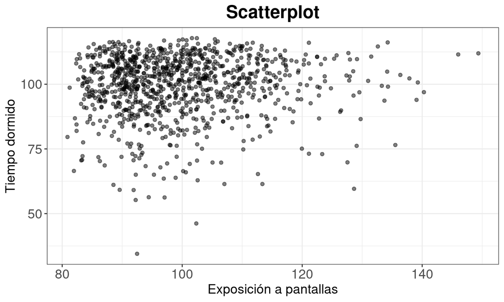

## Pantallas vs. Puntaje

Analizamos gráficamente el vínculo entre la variable de uso de pantallas con la variable de uso de puntaje obtenido. ¿Observa algún vínculo?

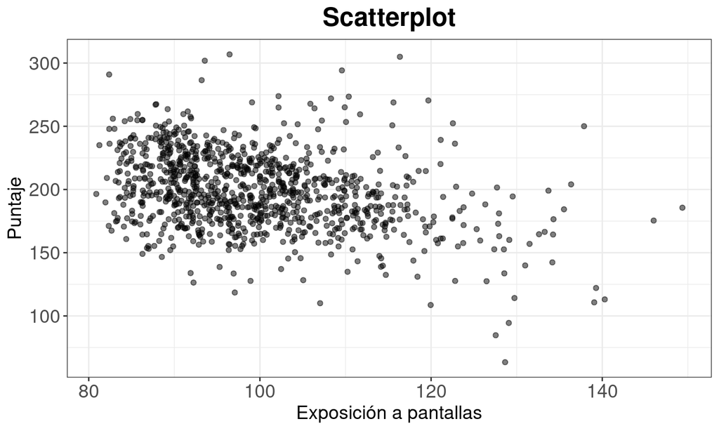

## Sueño vs. Puntaje

Analizamos gráficamente el vínculo entre la variable de calidad de sueño con la variable de puntaje obtenido. ¿Observa algún vínculo?

[figure not shown]

## Conclusiones

En general, no se observa ningún vínculo significativo entre ningún par de variables. Hay tendencias crecientes y decrecientes, pero muy tenues.

Lo que sí se observa es que las tendencias parecen ser más fuertes cuando se buscan vínculos con los puntajes, pero aún así no es concluyente.

## Análisis bivariado por grupos

## Análisis bivariado por grupos

Nuevamente, al juntar ambos grupos podemos estar ocultando una tendencia que sea específica por cada test. Por lo tanto, podemos comparar los scatterplots dividiendo las variables por grupo.

## Hidratación vs. Alimentación

Analizamos gráficamente el vínculo entre la variable de hidratación con la variable de alimentación, separado por tests. ¿Observa diferencias?

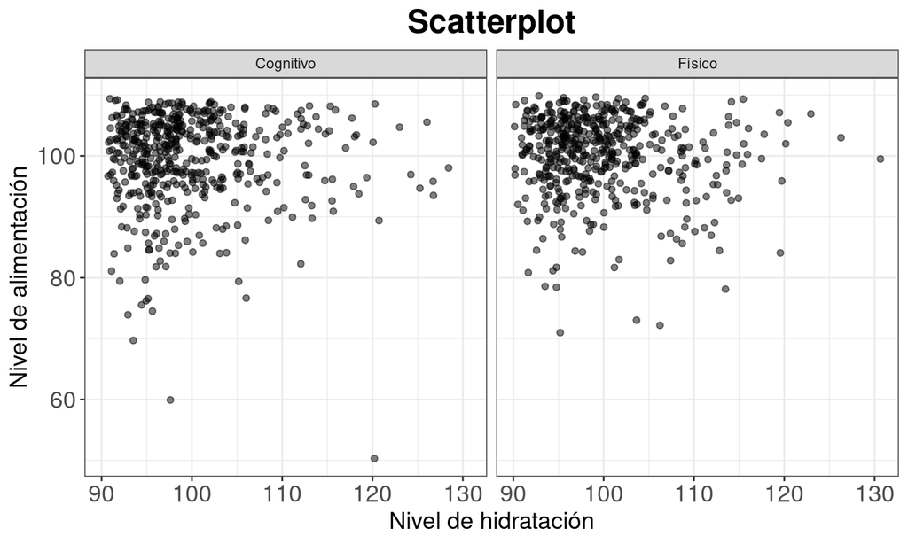

## Hidratación vs. Pantallas

Analizamos gráficamente el vínculo entre la variable de hidratación con la variable de uso de pantallas, separado por tests. ¿Observa diferencias?

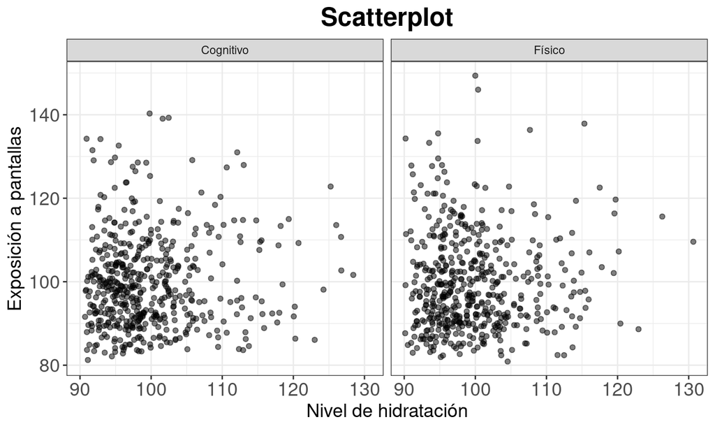

## Hidratación vs. Sueño

Analizamos gráficamente el vínculo entre la variable de hidratación con la variable de calidad de sueño, separado por tests. ¿Observa diferencias?

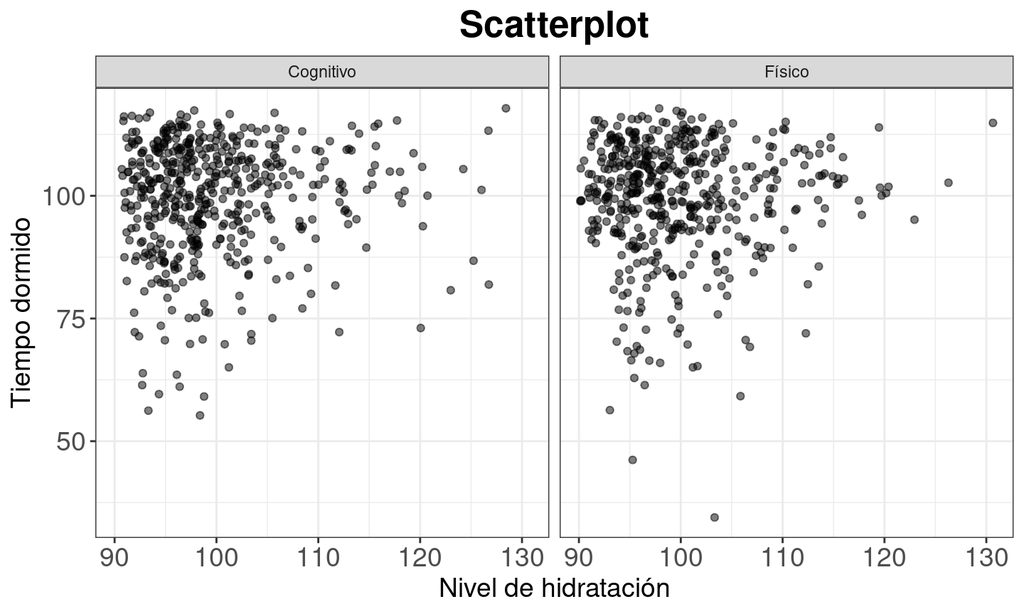

## Hidratación vs. Puntaje

Analizamos gráficamente el vínculo entre la variable de hidratación con la variable de puntaje obtenido, separado por tests. ¿Observa diferencias?

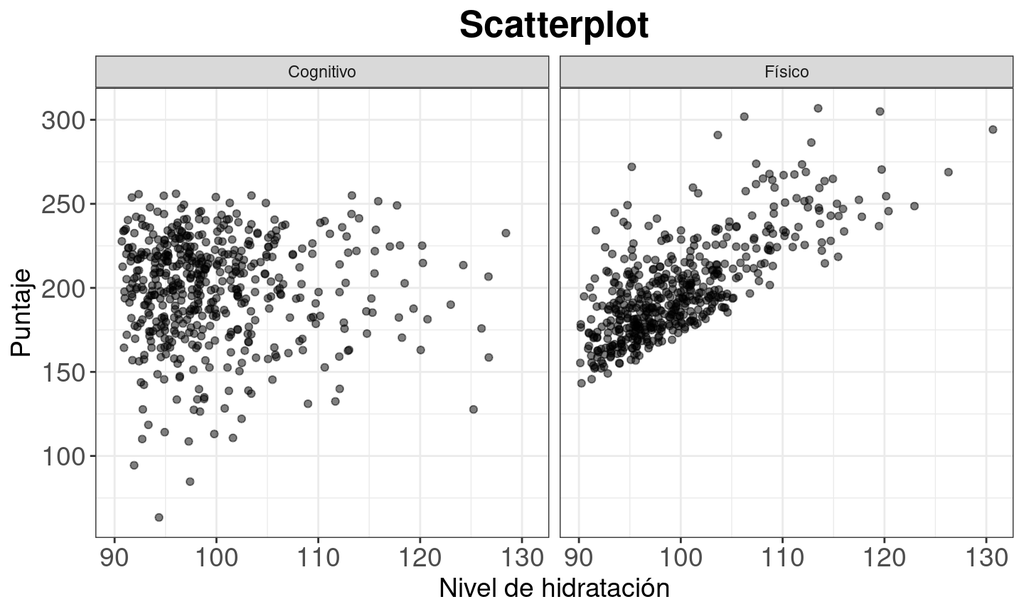

## Alimentación vs. Pantallas

Analizamos gráficamente el vínculo entre la variable de alimentación con la variable de uso de pantallas, separado por tests. ¿Observa diferencias?

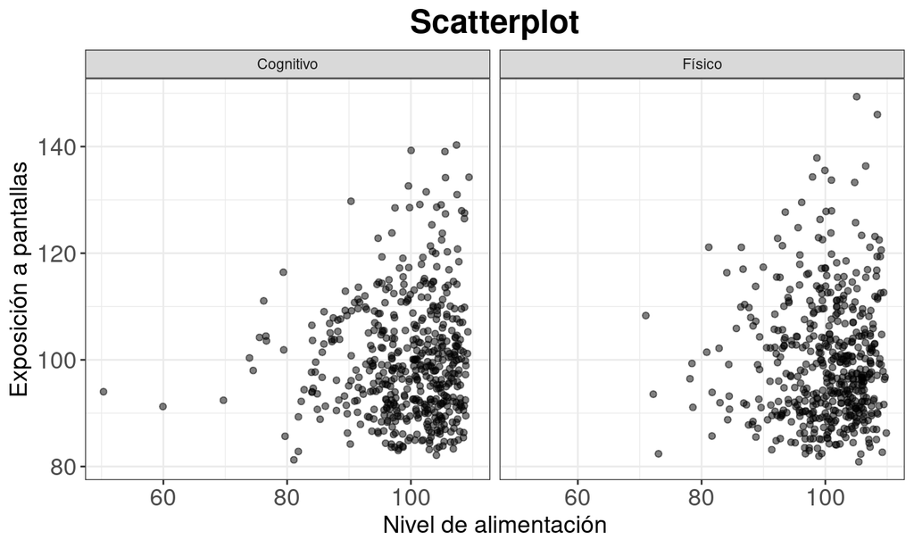

## Alimentación vs. Sueño

Analizamos gráficamente el vínculo entre la variable de alimentación con la variable de calidad de sueño, separado por tests. ¿Observa diferencias?

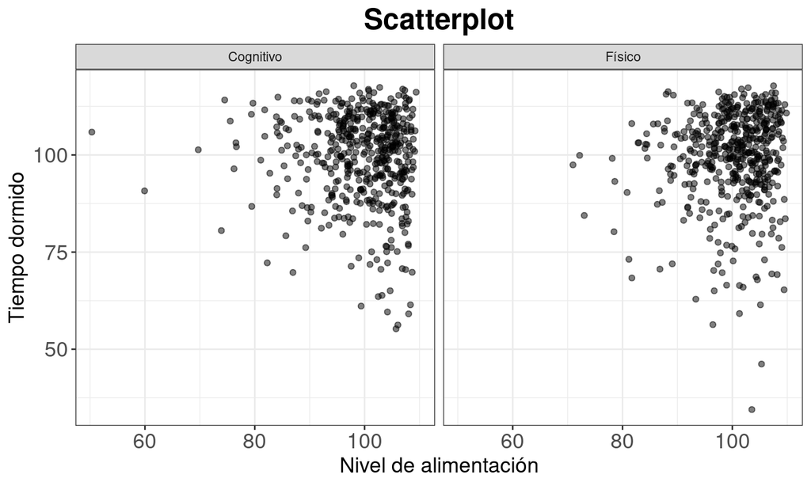

## Alimentación vs. Puntaje

Analizamos gráficamente el vínculo entre la variable de alimentación con la variable de puntaje obtenido, separado por tests. ¿Observa diferencias?

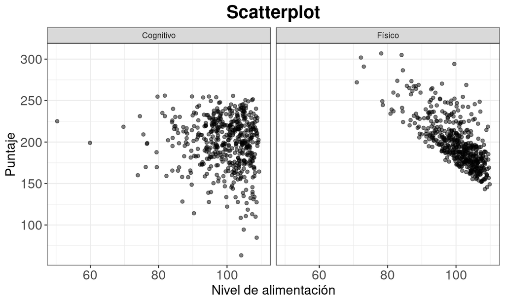

## Pantallas vs. Sueño

Analizamos gráficamente el vínculo entre la variable de uso de pantallas con la variable de calidad de sueño, separado por tests. ¿Observa diferencias?

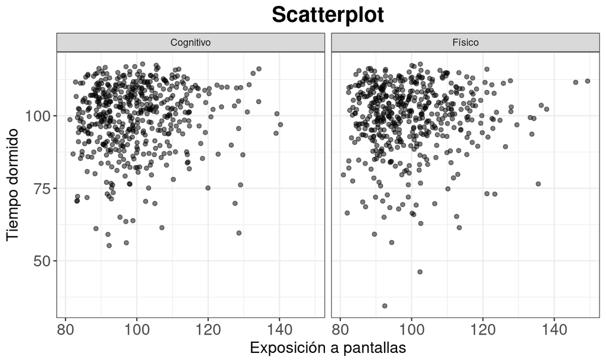

## Pantallas vs. Puntaje

Analizamos gráficamente el vínculo entre la variable de uso de pantallas con la variable de puntaje obtenido, separado por tests. ¿Observa diferencias?

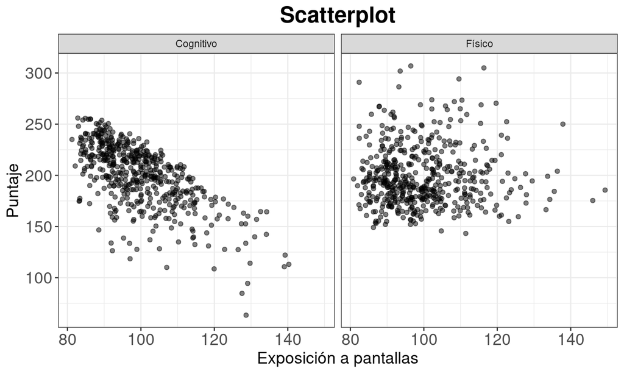

## Sueño vs. Puntaje

Analizamos gráficamente el vínculo entre la variable de calidad de sueño con la variable de puntaje obtenido, separado por tests. ¿Observa diferencias?

[figure not shown]

## Conclusiones

En este caso, vemos claramente cómo los únicos scatterplots que cambian significativamente por grupo son los vinculados al puntaje:

## Análisis Multivariado

## Análisis Multivariado

El análisis multivariado busca patrones analizando varias variables al mismo tiempo, considerando sus distintas combinaciones.

Gráficamente, sólo podemos ver en simultáneo 3 variables cuantitativas mediante un scatterplot de tres dimensiones.

## Hidratación vs. Alimentación vs. Pantallas

Analizamos gráficamente el vínculo conjunto entre la variable de hidratación con la variable de alimentación y la variable de uso de pantallas. ¿Observa algún vínculo?

[interactive chart not shown]

## Hidratación vs. Alimentación vs. Sueño

Analizamos gráficamente el vínculo conjunto entre la variable de hidratación con la variable de alimentación y la variable de calidad de sueño. ¿Observa algún vínculo?

[interactive chart not shown]

## Hidratación vs. Alimentación vs. Puntaje

Analizamos gráficamente el vínculo conjunto entre la variable de hidratación con la variable de alimentación y la variable de puntaje obtenido. ¿Observa algún vínculo?

[interactive chart not shown]

## Alimentación vs. Pantallas vs. Sueño

Analizamos gráficamente el vínculo conjunto entre la variable de alimentación con la variable de uso de pantallas y la variable de calidad de sueño. ¿Observa algún vínculo?

[interactive chart not shown]

## Alimentación vs. Pantallas vs. Puntaje

Analizamos gráficamente el vínculo conjunto entre la variable de alimentación con la variable de uso de pantallas y la variable de puntaje obtenido. ¿Observa algún vínculo?

[interactive chart not shown]

## Pantallas vs. Sueño vs. Puntaje

Analizamos gráficamente el vínculo conjunto entre la variable de uso de pantallas con la variable de calidad de sueño y la variable de puntaje obtenido. ¿Observa algún vínculo?

[interactive chart not shown]

## Conclusiones

Nuevamente, en consonancia con los scatterplots, las tendencias no son claras en ningún caso, pero son ligeramente más notorias cuando se involucran los puntajes.

## Análisis Multivariado por grupos

## Análisis Multivariado por grupos

Al análisis podemos agregarle otra dimensión considerando una variable categórica, que nos permite dividir en grupos.

## Hidratación vs. Alimentación vs. Puntaje (Test Físico)

Analizamos gráficamente el vínculo conjunto entre la variable de hidratación con la variable de alimentación y la variable de puntaje obtenido, separando el grupo que se sometió al test físico. ¿Observa algún vínculo?

[interactive chart not shown]

## Hidratación vs. Alimentación vs. Puntaje (Test Cognitivo)

Analizamos gráficamente el vínculo conjunto entre la variable de hidratación con la variable de alimentación y la variable de puntaje obtenido, separando el grupo que se sometió al test cognitivo. ¿Observa algún vínculo?

[interactive chart not shown]

## Pantallas vs. Sueño vs. Puntaje (Test Físico)

Analizamos gráficamente el vínculo conjunto entre la variable de uso de pantallas con la variable de calidad de sueño y la variable de puntaje obtenido, separando el grupo que se sometió al test físico. ¿Observa algún vínculo?

[interactive chart not shown]

## Pantallas vs. Sueño vs. Puntaje (Test Cognitivo)

Analizamos gráficamente el vínculo conjunto entre la variable de uso de pantallas con la variable de calidad de sueño y la variable de puntaje obtenido, separando el grupo que se sometió al test cognitivo. ¿Observa algún vínculo?

[interactive chart not shown]

## Conclusiones

Lo que hasta ahora no era ninguna tendencia clara, ahora que observando las variables correctas en el grupo correcto:

- La hidratación tiene un impacto positivo en los puntajes del test físico, mientras que la alimentación tiene el efecto inverso. Además, ninguna de estas variables influye significativamente sobre los puntajes del test cognitivo.
- El tiempo dedicado al sueño tiene un impacto positivo en los puntajes del test cognitivo, mientras que el tiempo dedicado a las pantallas tiene el efecto inverso. Además, ninguna de estas variables influye significativamente sobre los puntajes del test físico.

## Conclusiones generales

## Objetivos del Análisis Multivariado

- A veces las relaciones entre variables pueden ser muy complejas y no observarse a simple vista.
- A su vez, cuando las variables son muchas es inabarcable hacer la cantidad de gráficos necesarios para detectar dichos patrones.
- El análisis multivariado se encarga de encontrar estos patrones generalmente a partir de matrices que representen a los datos o ciertas características de los datos.
- Los procedimientos pueden servir para detectar similitudes entre variables pero también entre observaciones.
- El análisis multivariado va más allá de los valores que toman las variables, sino que se basa en **las combinaciones** de valores de las distintas variables. Por ejemplo, puede que los **valores** que se observan sean comunes pero que **la combinación de los valores** no lo sea.

## Aplicaciones

## Aplicaciones

- Comportamiento de consumidores
  - Identificación de características comunes entre distintos grupos de clientes.
  - Valoración simultánea de distintas características de un producto por parte de los clientes.
- Finanzas
  - Resumir el inmenso número de variables que influyen sobre el mundo financiero en algunas combinaciones claves.
  - Analizar las características de solicitantes de un préstamo para ver si califica o no para el mismo.

## Aplicaciones

- Biomedicina
  - Análisis de múltiples factores que pueden influir sobre el resultado de un tratamiento.
  - Búsqueda de patrones entre las expresiones de distintos genes para entender los mecanismos regulatorios de las células.
- Ingeniería
  - Control de calidad considerando distintas características de un producto.

## RMarkdown

## RMarkdown

RMarkdown es un tipo de documento de R que puede generar presentaciones o documentos interactivos con códigos o outputs de código de distintos lenguajes de programación, con la posibilidad de intercalar texto. Estas características permiten confeccionar documentos de alta calidad, versatilidad y logrando un aspecto muy profesional.

## Tipo de Documento

Luego se puede elegir el tipo de documento, en general, suele ser un pdf o un html:

[figure not shown]

## Fragmentos de código

Los archivos de RMarkdown permiten agregar fragmentos de código, se pueden utilizar distintos lenguajes de programación. Para algunos lenguajes, es necesario incluir paquetes que vinculen el lenguaje de programación con `R`. Por ejemplo, para utilizar python es necesario incluir el paquete `reticulate`.

[figure not shown]